# Text Analytics Boston useR

# **Text Mining & Visualization**

## About Me

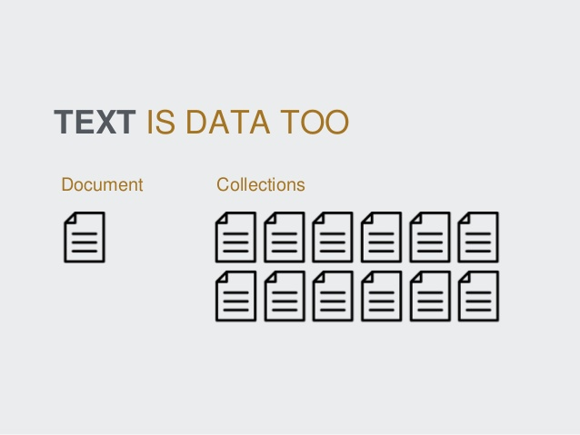

### - BS in Applied Science from US Coast Guard Academy; studed heavy metals in surface waters

### - MS in Chemisry researching organometallic semiconductors

### - MBA in Finance

### - Spent most of my career in Catastrophe Risk Modeling in the insurance industry

### - Also worked in banking, marketing, and insuretech

## Why Text Mining

[figure not shown]

## Text Analytics & Natural Language Processing

### Generally Consists of Three Phases

### * Text analytics and visualization

#### - Consists of theming, keyword(key phrase) searching, tokenization and visualization

### * Predictive modeling with text as the independent variables (NLP)

#### - Can employ deep learning models or traditional ‘bag of words’ models

### * Chatbots and AI

### Process

[figure not shown]

## Requires Specialized Libraries

### Not all are used here, but this is a good list

### Additional supporting libraries for modeling

### Order of library loading matters due to overlap and masking

```r
library(ggplot2)
library(reshape2)
library(scales)
library(readxl)
library(SnowballC)  # Porter's word stemming
library(textstem)  # Perform setmming and lemmatization
library(tm)  # Text Cleaning and Processing
library(RTextTools)  # Automatic Text Classification via Supervised Learning
library(stringi)  # For processing strings
library(wordcloud)  # Plot word clouds
library(wordcloud2)  # Fancy plotting of word clouds
library(RWeka)  # Machine Learning Java Library for Tokenization
library(tidytext)  # Additional Text Processing Library (new release)
library(tidyr)
library(knitr)
library(dendextend)  # Making Dendograms
library(dendextendRcpp)  # Supporting package for dendextend
library(qdap)  # Bridge Gap Between Qualitative Data and Quantitative Analysis

library(topicmodels)  # For LDA


# Modeling Libraries
library(caret)
library(Metrics)
library(pROC)
library(naivebayes)  # Naive Bayes package
library(klaR)  # Alternative NB package
library(e1071)  # Windows specific modeling package best NB package
library(caTools)  # Utility function to help modeling split
library(randomForest)

# Manipulating Data
library(dplyr)
```

## Understanding Stemming and Lemmatization

### Not always used

### - Stemming is a process that removes endings such as affixes.

### - Lemmatization is the process of grouping inflected forms together as a single base form.

```r
wv <- c('wolves', 'dogs', 'cats', 'birdies')
```

```r
textstem::stem_words(wv)
```

```
## [1] "wolv"  "dog"   "cat"   "birdi"
```

```r
lemmatize_words(wv)
```

```
## [1] "wolf"   "dog"    "cat"    "birdie"
```

## TF-IDF

### TF-IDF: Term Frequency-Inverse Document Frequency

- Reflects how important a word is to a document in a collection or corpus
- Example:
- Doc 1 “this is a sample text”
- Doc 2 “this example is another example of text”
- tf(“this”, doc 1) = 1/5
- tf(“this”, doc 2) = 1/7
- idf(“this”, Corpus) = log(counts/documents that contain word) = log(2/2) = 0
- tfidf(“this”, doc 1) = .2 * 0 = 0
- tfidf(“this”, doc 2) = .14 * 0 = 0

### “this” is not that informative since it appears in all documents

- Use the word “example”
- tf(“example”, doc 1) = 0/5 = 0
- tf(“example”, doc 2) = 2/7 = .285
- idf(“example”, Corpus) = log(2/1) = .301 (base 10)
- tfidf(“example”, doc 1) = 0 * .301 = 0
- tfidf(“example”, doc 2) = .2854 * .301 = 0.0857

### Unique words get a higher score

## Text Often Needs Preliminary Cleaning

```r
# Get the region and text
textData <- survey %>% dplyr::select(LikeMost,
                              Region)

# Remove NA
textData <- na.omit(textData)

# First step in Processing
textData$LikeMost <- tolower(textData$LikeMost)

# remove the 'na', 'n/a' using a grob vs text substitution
# this is like a regex
grx <- glob2rx('*na*|*n/a*')
cleanData <- subset(textData, subset = !grepl(grx, textData$LikeMost))

# adjust the stopwords so that ngatives are included
# create revised stopwords list to include some key words in keep
newWords <- stopwords("english")
keep <- c("no", "more", "not", "can't", "cannot", "isn't", "aren't", "wasn't",
          "weren't", "hasn't", "haven't", "hadn't", "doesn't", "don't", "didn't", "won't")
newWords <- newWords [! newWords %in% keep]

# clean up the words from hidden chars and convert to utf-8
cleanData$LikeMost <- iconv(cleanData$LikeMost, to = "utf-8")
```

## Standard Pre-processing and Tokenizing

### - Order of steps matters, especially punctuation, need to remove it after you remove contraction words

### - tm_map function allows for functions to be added like stemming and lemmatization

### - Set token value to 2 for creating bigrams

```r
like <- VCorpus(VectorSource(cleanData$LikeMost))
like <- tm_map(like,PlainTextDocument)
like <- tm_map(like, removeWords, newWords)
like <- tm_map(like, removeWords, c("i", "like"))
like <- tm_map(like, removePunctuation)
like <- tm_map(like, removeNumbers)
like <- tm_map(like, stripWhitespace)

tokens <- 2
MygramTokenizer <- function(x) {NGramTokenizer(x, Weka_control(min = tokens, max = tokens))}

# make the TDM
likeTDM <- TermDocumentMatrix(like, control = list(tokenize = MygramTokenizer))
# dim(likeTDM)
print(likeTDM$dimnames$Terms[1:100])
```

```
##   [1] "abetment government"   "ability pay"
##   [3] "ability place"         "able consult"
##   [5] "able contact"          "able line"
##   [7] "able pick"             "able speak"
##   [9] "absolutely nothing"    "access humans"
##  [11] "access quick"          "access responsive"
##  [13] "access transparent"    "accessibility claim"
##  [15] "accident forgiveness"  "accident response"
##  [17] "accident theft"        "accidental activity"
##  [19] "account access"        "acct automatically"
##  [21] "acsess informed"       "action quickly"
##  [23] "actual able"           "adequate coverage"
##  [25] "adons upsells"         "afford vet"
##  [27] "affordable coverage"   "affordable dependable"
##  [29] "affordable havent"     "affordable local"
```

[output cut: 35 more lines]

```r
tokenMatrix <- as.matrix(likeTDM)
# Sort it most frequent to least frequent and create a table
tokenV <- sort(rowSums(tokenMatrix), decreasing = TRUE)
token.d <- data.frame(word = names(tokenV), freq=tokenV)
table(token.d$freq)
```

```
##
##    1    2    3    4    5    7    9   10   15   18
## 1225   77   20    7    5    1    1    1    1    1
```

## Tokenizing Text

### Use a Term Document Matrix

### - Tokenizing splits phrases into tokens

#### - Words, Bigrams, Trigrams, etc.

### - TDM Terms are rows, documents are columns, values are counts

### - The transpose is a DTM, where documents are rows and terms are columns

### - Each has separate uses, DTM is used when there are factors

```r
likeTDM <- TermDocumentMatrix(like, control = list(tokenize = MygramTokenizer))
# dim(likeTDM)
# print(likeTDM$dimnames$Terms)

tokenMatrix <- as.matrix(likeTDM)
# sort it most frequent to least frequent and create a table
tokenV <- sort(rowSums(tokenMatrix), decreasing = TRUE)
token.d <- data.frame(word = names(tokenV), freq=tokenV)
table(token.d$freq)
```

```
##
##    1    2    3    4    5    7    9   10   15   18
## 1225   77   20    7    5    1    1    1    1    1
```

```r
head(token.d, 20)
```

```
##                              word freq
## pricing coverage pricing coverage   18
## customer service customer service   15
## good coverage       good coverage   10
## not sure                 not sure    9
## local agent           local agent    7
## dont know               dont know    5
## good price             good price    5
## insurance agent   insurance agent    5
## low cost                 low cost    5
## peace mind             peace mind    5
## coverage good       coverage good    4
## full coverage       full coverage    4
## good service         good service    4
## not much                 not much    4
## one agent               one agent    4
## one company           one company    4
## price coverage     price coverage    4
## agent responsive agent responsive    3
## coverage price     coverage price    3
## coverage pricing coverage pricing    3
```

## Plot a Cloud of the Phrases

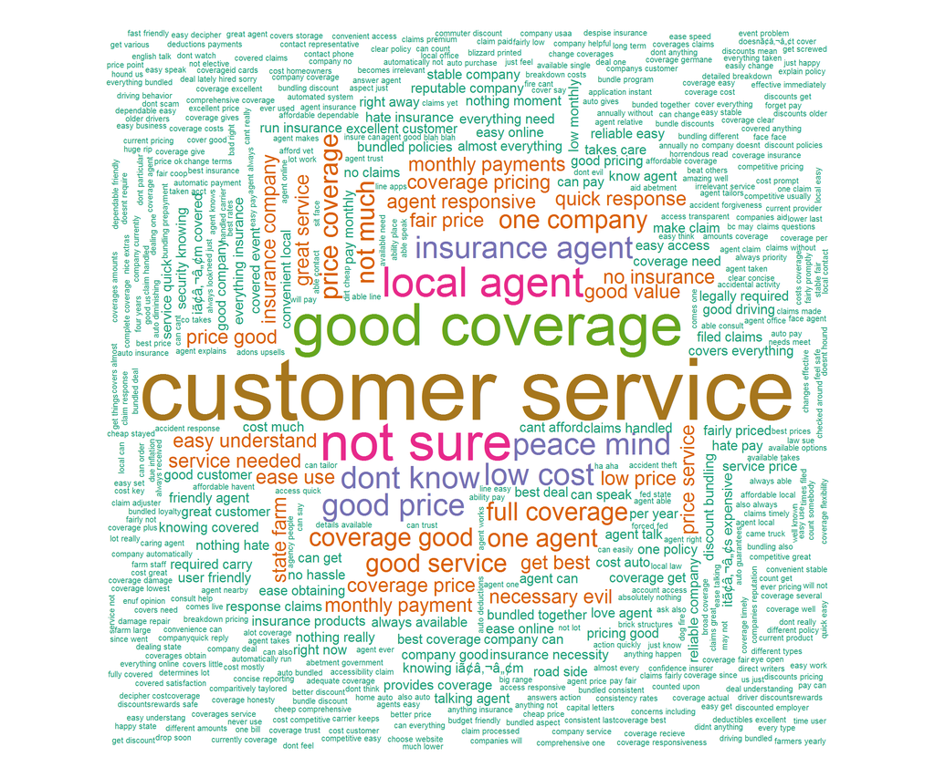

```r
wordcloud(token.d$word, token.d$freq,scale=c(8,.2), min.freq = 1, max.words = 1000,
          random.order = FALSE,rot.per=0.15, use.r.layout=FALSE,
          colors = brewer.pal(8,"Dark2"))
```

## Standard Text Pre-Processing

- Make two passes: initial to get into format for corpus and then process corpus

```r
# First cleaning to prepare for corpus
textData$LikeMost <- tolower(textData$LikeMost)
textData$LikeMost <- iconv(textData$LikeMost, to = "utf-8")
cleanText <- textData %>% filter(! is.na(textData$LikeMost))


# Standard pre-processing
like <- VCorpus(VectorSource(cleanText$LikeMost))
like <- tm_map(like,PlainTextDocument)
like <- tm_map(like, removeWords, newWords)
like <- tm_map(like, removePunctuation)
like <- tm_map(like, removeWords, c("i", "like", "na"))
like <- tm_map(like, removeNumbers)
like <- tm_map(like, stripWhitespace)
```

## Hierarchical Clustering

### Uses a Document Term Matrix so we can use the factors in the data

### - Convert the DTM to a data frame

### - Attach the Region Dimension to the DTM

```r
# Make Document Term Matrix
# Preserves the Document Order to Attach Factors
likeDTM <- DocumentTermMatrix(like)

# Convert it to a data frame via matrix
# Collapse it down to region (9 obseravations)
textDF <- as.data.frame(as.matrix(likeDTM))
textDF$Region <- as.factor(cleanText$Region)
dfRegion <- aggregate(textDF[,-length(textDF)], by = list(textDF$Region), sum)

# Remove sparse terms and columns by picking columns that sum to 5 or more
# Setting the sum equal to a frequency for the entire set
dfRegionRed <- dfRegion[,colSums(dfRegion[,2:length(dfRegion)]) > 5]
rownames(dfRegionRed) <- dfRegion[,1]

# Create a correlation matrix and make it a distance matrix
words <- length(dfRegionRed)
dis <- as.dist(1 - cov2cor(cov(dfRegionRed[,c(1:words)],
                               method = "pearson",
                               use = "pairwise.complete.obs")))
```

## Dendrogram of Hierarchical Clusters

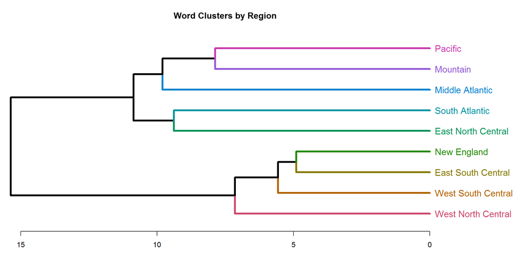

```r
par(mar = c(3.5, .5, 3.5, 9))
d <- dist(dfRegionRed, method = "euclidean")
hc <- hclust(d)
dend <- d %>% hclust %>% as.dendrogram
labels_cex(dend) <- 1.25
dend %>%
  color_branches(k=9) %>%
  color_labels(9) %>%
  highlight_branches_lwd(4) %>%
  plot(horiz=TRUE, main = "Word Clusters by Region", axes = T, xlim = c(15,0))
```

## Tidytext Library

### - New library using Tidyverse format

### - Employs a different set of commands and can achieve similar results

### - Make a new plot that gives a more in-depth view by word

```r
# Get the data and do initial formatting
textData <- survey %>%
  select(LikeMost,
         Region)
textData <- na.omit(textData)
textData$LikeMost <- tolower(textData$LikeMost)

# Remove the 'na', 'n/a'
grx <- glob2rx('*na*|*n/a*')
cleanData <- subset(textData, subset = !grepl(grx, textData$LikeMost))

# Simplify the Regions
cleanData$Region <- ifelse(cleanData$Region == 'East North Central', 'Central', cleanData$Region)
cleanData$Region <- ifelse(cleanData$Region == 'East South Central','Central', cleanData$Region)
cleanData$Region <- ifelse(cleanData$Region == 'West North Central','Central', cleanData$Region)
cleanData$Region <- ifelse(cleanData$Region == 'West South Central','Central', cleanData$Region)

# Make Region a Factor
cleanData$Region = as.factor(cleanData$Region)

# Count Words by region
like_words <- cleanData %>%
  unnest_tokens(word, LikeMost) %>%
  count(Region, word, sort = T) %>%
  ungroup()

head(like_words, 10)
```

```
## # A tibble: 10 x 3
##    Region         word         n
##    <fct>          <chr>    <int>
##  1 Central        i           71
##  2 Central        coverage    67
##  3 Central        and         53
##  4 South Atlantic coverage    51
##  5 Central        to          48
##  6 Central        the         45
##  7 Central        my          33
##  8 South Atlantic i           33
##  9 Central        agent       32
## 10 South Atlantic and         31
```

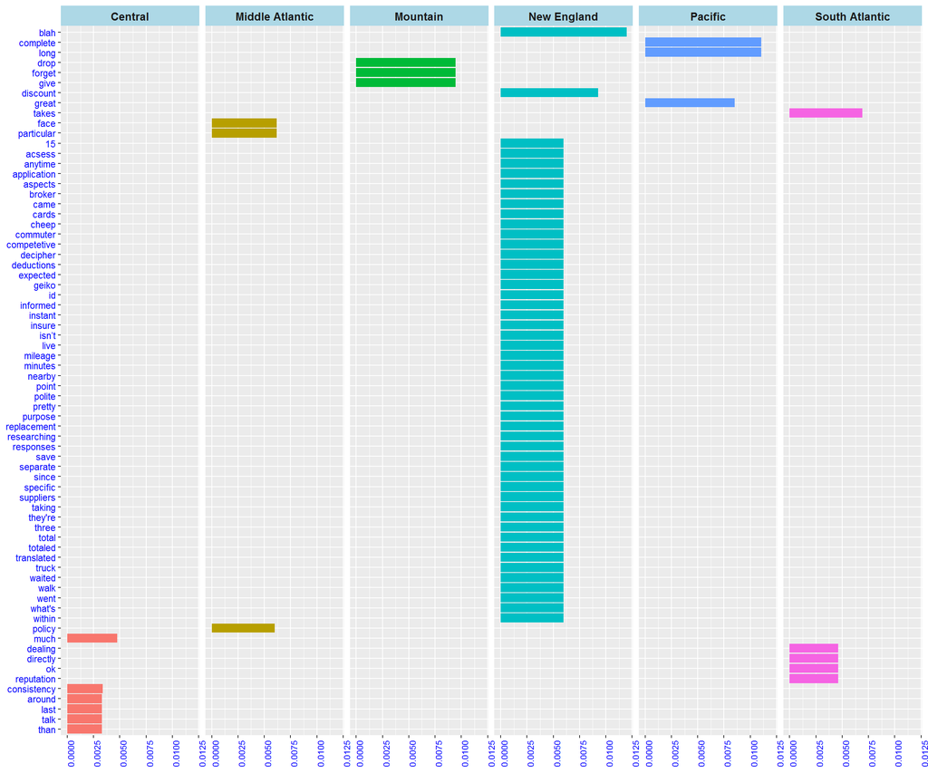

```r
# Calculate tf_idf
plot_like <- like_words %>%
  bind_tf_idf(word, Region, n) %>%
  arrange(desc(tf_idf)) %>%
  mutate(word = factor(word, levels = rev(unique(word))))

# Make the plot
plot_like %>%
  group_by(Region) %>%
  top_n(3, tf_idf) %>%
  ungroup() %>%
  mutate(word = reorder(word, tf_idf)) %>%
  ggplot(aes(word, tf_idf, fill = Region)) +
  geom_col() + coord_flip() +
  facet_wrap(~Region, nrow = 1) +
  theme_bryan() + theme(legend.position = '')
```

## Plotting Bigrams

```
## # A tibble: 6 x 3
## # Groups:   Term [1]
##   Term                Region          Total
##   <chr>               <fct>           <dbl>
## 1 abetment government Central             0
## 2 abetment government Middle Atlantic     1
## 3 abetment government Mountain            0
## 4 abetment government New England         0
## 5 abetment government Pacific             0
## 6 abetment government South Atlantic      0
```

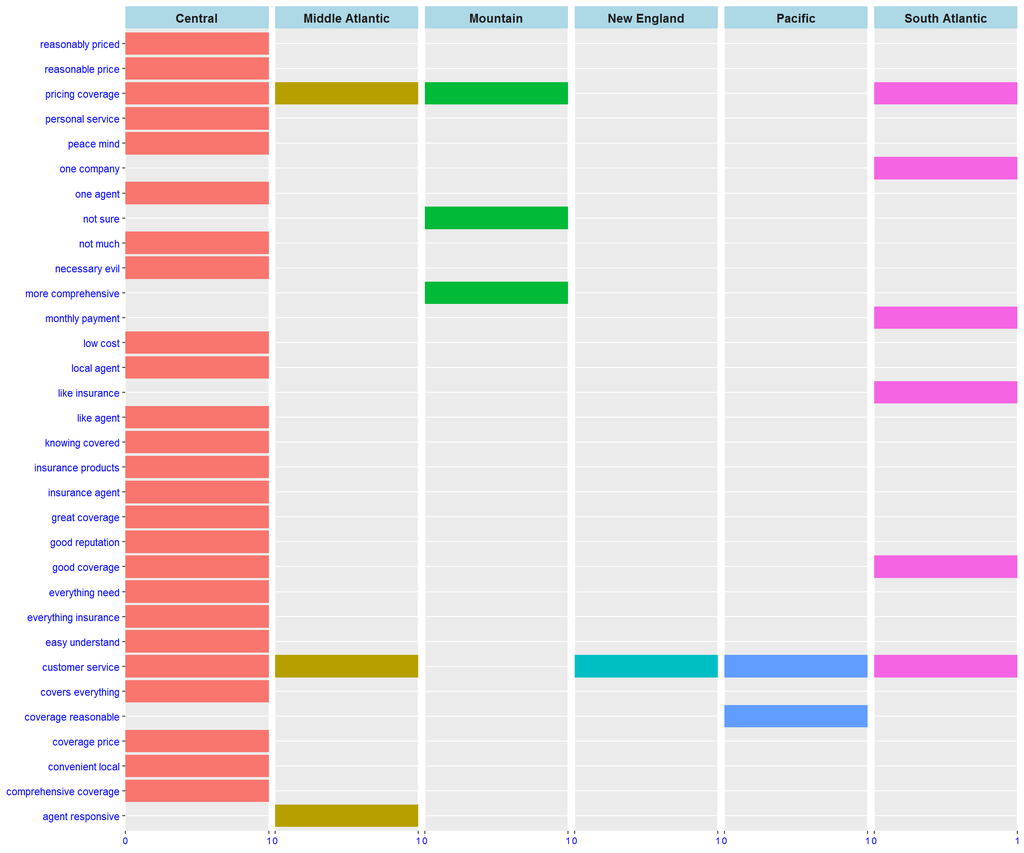

## Plotting Bigrams with Lemmatization

### There is some change in the terms from first plot

```
## # A tibble: 6 x 3
## # Groups:   Term [1]
##   Term                Region          Total
##   <chr>               <fct>           <dbl>
## 1 abetment government Central             0
## 2 abetment government Middle Atlantic     1
## 3 abetment government Mountain            0
## 4 abetment government New England         0
## 5 abetment government Pacific             0
## 6 abetment government South Atlantic      0
```

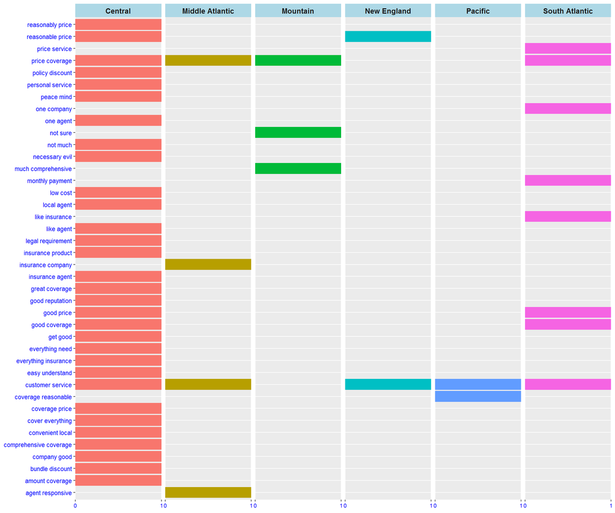

## Word Associations and Frequencies

### - TM package has supporting functions for frequency and correlation

### - Correlation is calculated from the DTM

```r
### Words with at least three mentions
findFreqTerms(likeDTM, lowfreq = 3, highfreq = Inf)
```

```
##  [1] " ¬â"                " ¢s"                " ¢t"
##  [4] "¬â "                "agent responsive"    "bundle discount"
##  [7] "claim handle"        "company good"        "cover everything"
## [10] "coverage good"       "coverage need"       "coverage price"
## [13] "coverage reasonable" "customer service"    "dont know"
## [16] "ease use"            "easy understand"     "fair price"
## [19] "full coverage"       "get good"            "good coverage"
## [22] "good price"          "good service"        "good value"
## [25] "great coverage"      "great service"       "iã¢â "
## [28] "insurance agent"     "insurance company"   "insurance product"
## [31] "itã¢â "             "know agent"          "know cover"
## [34] "like agent"          "like anything"       "like coverage"
## [37] "local agent"         "low cost"            "low price"
## [40] "make claim"          "monthly payment"     "much insurance"
## [43] "necessary evil"      "no insurance"        "not much"
## [46] "not sure"            "nothing like"        "one agent"
## [49] "one company"         "pay claim"           "pay monthly"
## [52] "peace mind"          "personal service"    "price coverage"
## [55] "price good"          "price service"       "quick response"
## [58] "reasonable price"    "reasonably price"    "service need"
## [61] "service price"       "state farm"          "take care"
```

```r
### Words Correlated to "customer service" with at least .25
keyTerm <- "customer service"
wordAssoc <- findAssocs(likeDTM, keyTerm, .25)

# Convert to a dataframe
wordAssocDF <- data.frame(Corr=as.numeric(unlist(wordAssoc)),
                          Terms = gsub(paste(keyTerm,'.', sep = ''),'',names(unlist(wordAssoc))))

head(wordAssocDF)
```

```
##   Corr              Terms
## 1 0.36 excellent customer
## 2 0.36      good customer
## 3 0.36     great customer
## 4 0.36      service quick
## 5 0.26     always receive
## 6 0.26         amaze good
```

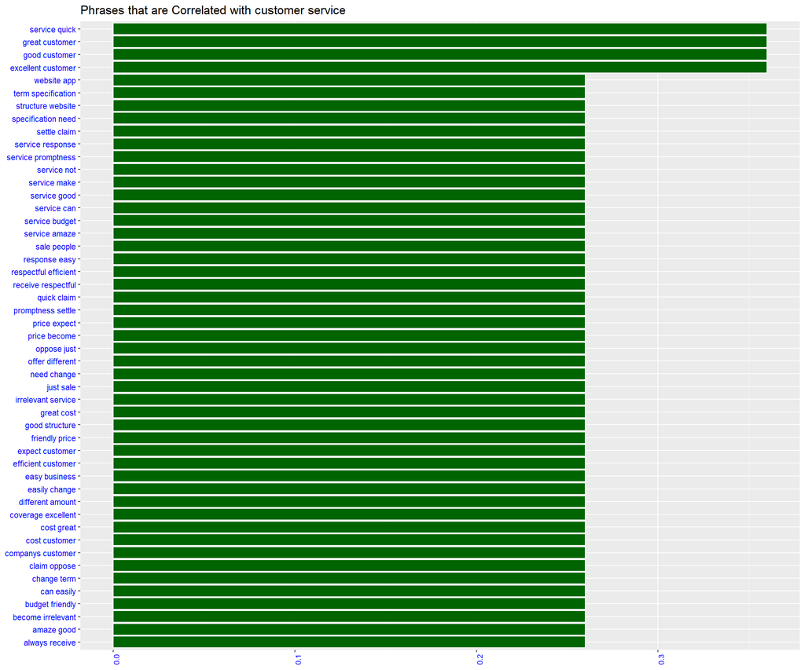

```r
# Plot it
wordP <- ggplot(wordAssocDF, aes(y = Corr, x = reorder(Terms, Corr))) +
  geom_col(position = 'stack', color = 'white', fill = 'dark green') +
  coord_flip() +
  # shape = 23, size = 3, fill = 'white'
  ggtitle(paste("Phrases that are Correlated with", keyTerm)) +
            xlab("Correlation of Terms") +
            ylab("Terms (Most Frequent at Top)") +
            theme_bryan()

wordP
```

## Natural Language Processing

### - Using words or phrases as variables in models

### - Traditional classification models: Random Forest, GLMNET, Naive Bayes

### - More advanced with Markov and Hidden Markov Models: sequencing

### - Deep learning with Recurrent Neural Networks

#### - Long Short-Term Memory (LSTM) models

#### - CNNs can work too, pick out key clusters of words

## Random Forest

### - Modeling performed without caret package

```r
setwd('N:/Bryan/Templates')
dataset_original = read.delim('Restaurant_Reviews.tsv', quote = '', stringsAsFactors = FALSE)


# Processing
# Note that this includes stemming
corpus = VCorpus(VectorSource(dataset_original$Review))
corpus = tm_map(corpus, content_transformer(tolower))
corpus = tm_map(corpus, removeNumbers)
corpus = tm_map(corpus, removePunctuation)
corpus = tm_map(corpus, removeWords, stopwords())
corpus = tm_map(corpus, stemDocument)
corpus = tm_map(corpus, stripWhitespace)

# Creating the Bag of Words model
# Reduce the variable size with removal of sparse terms
dtm = DocumentTermMatrix(corpus)
dtmRed = removeSparseTerms(dtm, 0.999)
dataset = as.data.frame(as.matrix(dtmRed))
dataset$Liked = dataset_original$Liked


# Encoding the target feature as factor
dataset$Liked <- ifelse(dataset$Liked==1,'yes','no')
dataset$Liked <- as.factor(dataset$Liked)


# Splitting the dataset into the Training set and Test set
set.seed(123)
split = sample.split(dataset$Liked, SplitRatio = 0.8)
training_set = subset(dataset, split == TRUE)
test_set = subset(dataset, split == FALSE)

# Fitting Random Forest Classification to the Training set
classifier = randomForest(x = training_set[-692],
                          y = training_set$Liked,
                          ntree = 10)

# Predicting the Test set results
y_pred = predict(classifier, newdata = test_set[-692])

# Making the Confusion Matrix
confusionMatrix(y_pred, test_set[, 692])
```

```
## Confusion Matrix and Statistics
##
##           Reference
## Prediction no yes
##        no  82  23
##        yes 18  77
##
##                Accuracy : 0.795
##                  95% CI : (0.7323, 0.8487)
##     No Information Rate : 0.5
##     P-Value [Acc > NIR] : <2e-16
##
##                   Kappa : 0.59
##  Mcnemar's Test P-Value : 0.5322
##
##             Sensitivity : 0.8200
##             Specificity : 0.7700
##          Pos Pred Value : 0.7810
##          Neg Pred Value : 0.8105
##              Prevalence : 0.5000
##          Detection Rate : 0.4100
##    Detection Prevalence : 0.5250
##       Balanced Accuracy : 0.7950
##
##        'Positive' Class : no
##
```

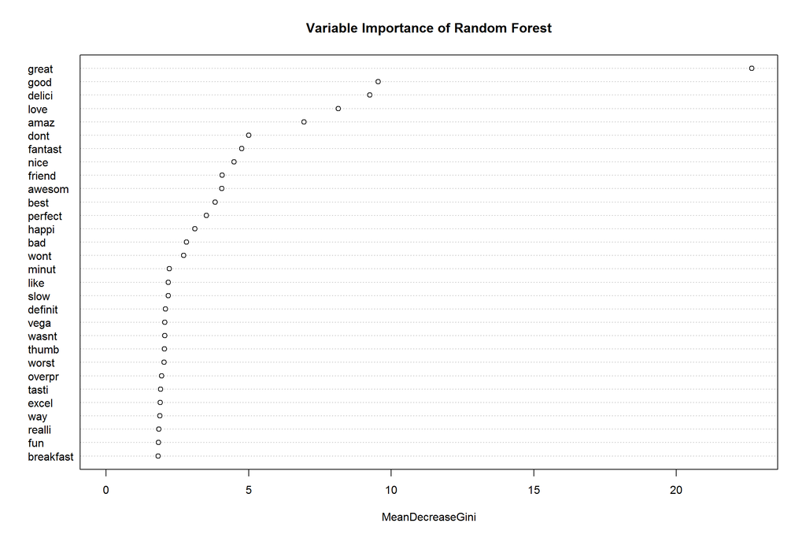

```r
varImpPlot(classifier, main = "Variable Importance of Random Forest")
```

## GLMNET

### - Elastic net classifier with caret package

### - Model uses same data as random forest

```r
# Use GLMNET model

# Create the names of the variables
# This is done in the Caret package
`%notin%` <- function(x,y) !(x %in% y)
allNames <- names(dataset)
outcomeNames <- c("Liked")
predictorNames <- allNames[allNames %notin% outcomeNames]
predictorNames
```

```
##   [1] "absolut"      "acknowledg"   "actual"       "ago"
##   [5] "almost"       "also"         "although"     "alway"
##   [9] "amaz"         "ambianc"      "ambienc"      "amount"
##  [13] "anoth"        "anyon"        "anyth"        "anytim"
##  [17] "anyway"       "apolog"       "appet"        "area"
##  [21] "arent"        "around"       "arriv"        "ask"
##  [25] "assur"        "ate"          "atmospher"    "attack"
##  [29] "attent"       "attitud"      "authent"      "averag"
##  [33] "avoid"        "away"         "awesom"       "awkward"
##  [37] "babi"         "bachi"        "back"         "bacon"
##  [41] "bad"          "bagel"        "bakeri"       "bar"
##  [45] "bare"         "bartend"      "basic"        "bathroom"
##  [49] "batter"       "bay"          "bean"         "beat"
##  [53] "beauti"       "becom"        "beef"         "beer"
##  [57] "behind"       "believ"       "belli"        "best"
```

[output cut: 158 more lines]

```r
# caret package modeling
outcome <- "Liked"
objControl <- trainControl(method = 'cv', number = 3, returnResamp = 'none',
                           summaryFunction = twoClassSummary, classProbs = TRUE)
objModel <- train(training_set[,predictorNames], training_set[,outcome],
                  method = 'glmnet',
                  metric = "ROC",
                  trControl = objControl)

# Raw predictions
predictions <- predict(object = objModel, test_set[,predictorNames], type = 'raw')
head(predictions)
```

```
## [1] yes yes yes no  no  no
## Levels: no yes
```

```r
postResample(pred = predictions, obs = as.factor(test_set[,outcome]))
```

```
## Accuracy    Kappa
##    0.795    0.590
```

```r
# Get probailities from predictions
predictions <- predict(object = objModel, test_set[,predictorNames], type = "prob")
head(predictions)
```

```
##          no       yes
## 1 0.2177667 0.7822333
## 2 0.1259669 0.8740331
## 3 0.1259669 0.8740331
## 4 0.8395278 0.1604722
## 5 0.5354040 0.4645960
## 6 0.5476751 0.4523249
```

```r
# Get the AUC from probs
auc <- roc(ifelse(test_set[,outcome]=="yes",1,0),predictions[[2]])
print(auc$auc)
```

```
## Area under the curve: 0.8841
```

```r
#  Confusion matrix
confusionMatrix(predict(object = objModel, test_set[,predictorNames], type = 'raw'),
                        test_set[,outcome])
```

```
## Confusion Matrix and Statistics
##
##           Reference
## Prediction no yes
##        no  82  23
##        yes 18  77
##
##                Accuracy : 0.795
##                  95% CI : (0.7323, 0.8487)
##     No Information Rate : 0.5
##     P-Value [Acc > NIR] : <2e-16
##
##                   Kappa : 0.59
##  Mcnemar's Test P-Value : 0.5322
##
##             Sensitivity : 0.8200
##             Specificity : 0.7700
##          Pos Pred Value : 0.7810
##          Neg Pred Value : 0.8105
##              Prevalence : 0.5000
##          Detection Rate : 0.4100
##    Detection Prevalence : 0.5250
##       Balanced Accuracy : 0.7950
##
##        'Positive' Class : no
##
```

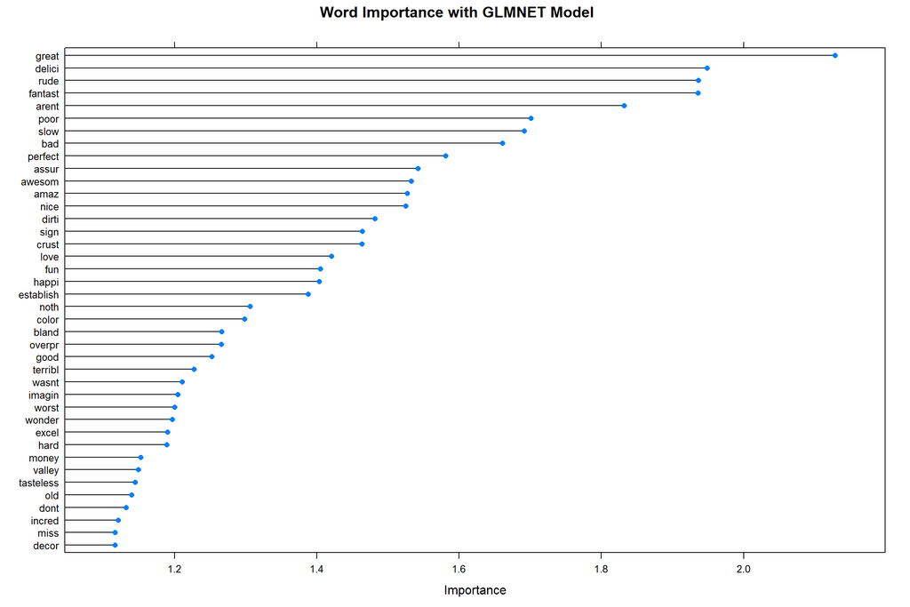

```r
#check for variable importance - top 40
plot(varImp(objModel, scale = F),top=40, main = " Word Importance with GLMNET Model")
```

## Naive Bayes

### - Very common model used with text

### - Use a dictionary created from the training set to reduce variables

### - Specify the model using e1071 package

#### - Multiple packages contain the NB algorithm

### - Variable importance plots are conditional probabilities

```r
# Shuffle the dataset first
set.seed(123)
dfShuffle <- dataset_original[sample(nrow(dataset_original)), ]
dfShuffle <- dataset_original[sample(nrow(dataset_original)), ]
glimpse(dfShuffle)
```

```
## Observations: 1,000
## Variables: 2
## $ Review <chr> "Stopped by this place while in Madison for the Ironman...
## $ Liked  <int> 1, 0, 0, 1, 0, 0, 1, 0, 1, 1, 1, 0, 0, 1, 0, 0, 1, 1, 0...
```

```r
# make the class variable
dfShuffle$Liked <- ifelse(dfShuffle$Liked==1,'yes','no')
dfShuffle$Liked <- as.factor(dfShuffle$Liked)

# Apply processing
corpus = VCorpus(VectorSource(dfShuffle$Review))
corpus = tm_map(corpus, content_transformer(tolower))
corpus = tm_map(corpus, removeNumbers)
corpus = tm_map(corpus, removePunctuation)
corpus = tm_map(corpus, removeWords, stopwords())
corpus = tm_map(corpus, stemDocument)
corpus = tm_map(corpus, stripWhitespace)
length(corpus)
```

```
## [1] 1000
```

```r
# Do a 80/20 split

set.seed(123)
split_ratio = .8
split = sample.split(dfShuffle$Liked, SplitRatio = split_ratio)
training_set = subset(dfShuffle, split == TRUE)
test_set = subset(dfShuffle, split == FALSE)

cut <- split_ratio * nrow(dfShuffle)

# Create a dtm, there are 1577 words
dtm = DocumentTermMatrix(corpus)

dtm_train <- dtm[1:cut,]
dtm_test <- dtm[(cut+1):nrow(dfShuffle),]

corpus_train <- corpus[1:cut]
corpus_test <- corpus[(cut+1):nrow(dfShuffle)]

# reduce using frequency
freq <- 5
wordFreq <- findFreqTerms(dtm_train, freq)
length((wordFreq))
```

```
## [1] 218
```

```r
dtm_train_nb <- DocumentTermMatrix(corpus_train, control=list(dictionary = wordFreq))
dim(dtm_train_nb)
```

```
## [1] 800 218
```

```r
dtm_test_nb <- DocumentTermMatrix(corpus_test, control=list(dictionary = wordFreq))
dim(dtm_test_nb)
```

```
## [1] 200 218
```

```r
# convert to matrix and data frame
training_set <- as.data.frame(as.matrix(dtm_train_nb))
testing_data <- as.data.frame(as.matrix(dtm_test_nb))
outcome <- dfShuffle$Liked[1:cut]
actual <- dfShuffle$Liked[(cut+1):nrow(dfShuffle)]
training_data <- cbind(outcome,training_set)


# Specify the model using e1071 package
objModel <- e1071::naiveBayes(outcome ~ ., data = training_data, laplace = 1)

# Raw classes - actually yields conditional probabilities
predictions <- predict(object = objModel, testing_data, type = 'raw')

# get the AUC Use the Raw Predictions
auc <- roc(ifelse(as.character(actual)=='yes',1,0),predictions[,2])
print(auc$auc)
```

```
## Area under the curve: 0.6074
```

```r
# Confusion matrix
confusionMatrix(predict(object = objModel, testing_data),
                actual)
```

```
## Confusion Matrix and Statistics
##
##           Reference
## Prediction no yes
##        no  36  14
##        yes 69  81
##
##                Accuracy : 0.585
##                  95% CI : (0.5134, 0.6541)
##     No Information Rate : 0.525
##     P-Value [Acc > NIR] : 0.05139
##
##                   Kappa : 0.1902
##  Mcnemar's Test P-Value : 3.08e-09
##
##             Sensitivity : 0.3429
##             Specificity : 0.8526
##          Pos Pred Value : 0.7200
##          Neg Pred Value : 0.5400
##              Prevalence : 0.5250
##          Detection Rate : 0.1800
##    Detection Prevalence : 0.2500
##       Balanced Accuracy : 0.5977
##
##        'Positive' Class : no
##
```

```r
# Unlist the tables
condProbs <- unlist(objModel$tables)
condProbDF <- data.frame(Prob=as.numeric(unlist(condProbs)),
                          Terms = names(unlist(condProbs)))
head(condProbDF)
```

```
##          Prob    Terms
## 1 0.007594937 absolut1
## 2 0.012345679 absolut2
## 3 0.086927462 absolut3
## 4 0.110559688 absolut4
## 5 0.012658228    also1
## 6 0.037037037    also2
```

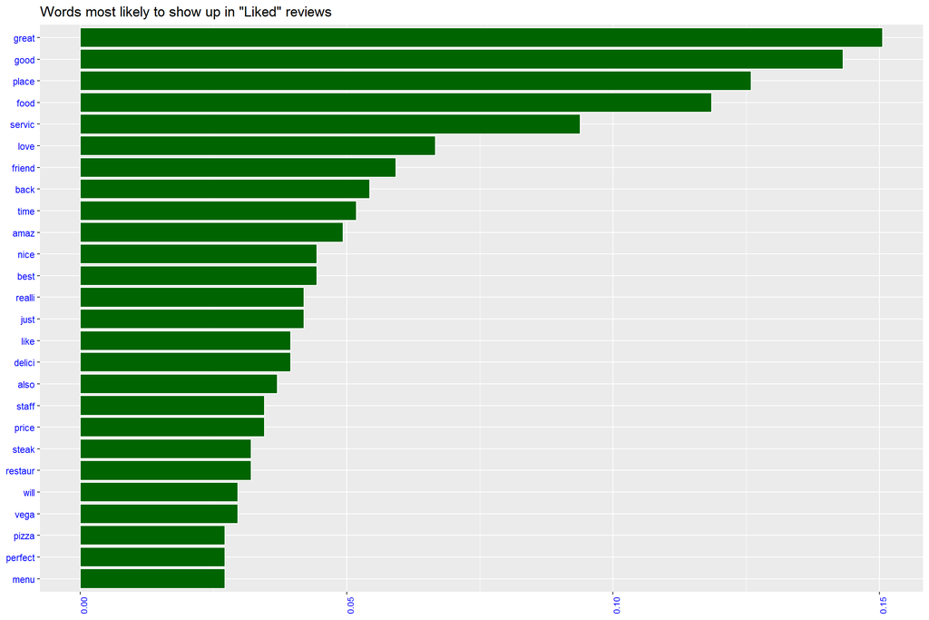

```r
# Likelihood of the word, given they liked the place
wordGivenLike <- condProbDF %>%
            mutate(CleanTerms = sub('2','',Terms)) %>%
            arrange(desc(Prob)) %>%
            filter(grepl('2', Terms))

# Likelihood of the word, given they did not like the place
wordGivenNotLike <- condProbDF %>%
  mutate(CleanTerms = sub('3','',Terms)) %>%
  arrange(desc(Prob)) %>%
  filter(grepl('3', Terms))

# Plots contributing to liking
wordRed <- wordGivenLike %>% filter(Prob > .025)
wordP <- ggplot(wordRed, aes(y = Prob, x = reorder(CleanTerms, Prob))) +
  geom_col(position = 'stack', color = 'white', fill = 'dark green') +
  coord_flip() +
  ggtitle('Words most likely to show up in "Liked" reviews') +
  ylab('Conditional Prob of Word Given They Liked It') +
  xlab('') +
  theme_bryan()
wordP
```

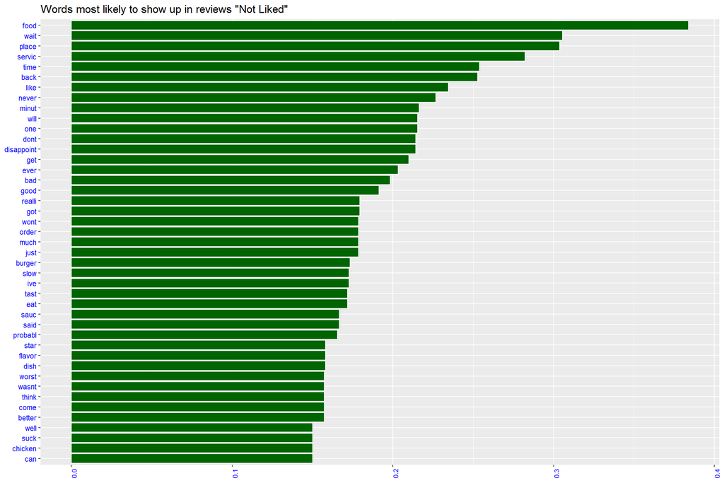

```r
# Make plots contributing to not liking
wordNotRed <- wordGivenNotLike %>% filter(Prob > .15)
wordP <- ggplot(wordNotRed, aes(y = Prob, x = reorder(CleanTerms, Prob))) +
  geom_col(position = 'stack', color = 'white', fill = 'dark green') +
  coord_flip() +
  ggtitle('Words most likely to show up in reviews "Not Liked" ') +
  ylab('Conditional Prob of Word Given They Did not Liked It') +
  xlab('') +
  theme_bryan()
wordP
```

## Phrases as Variables

### GLMNET Results

### - Model is focusing on negatives as driving classification

```
## [1] yes yes yes yes yes yes
## Levels: no yes
```

```
##         no      yes
## 1 0.469821 0.530179
## 2 0.469821 0.530179
## 3 0.469821 0.530179
## 4 0.469821 0.530179
## 5 0.469821 0.530179
## 6 0.469821 0.530179
```

```
## Area under the curve: 0.7368
```

```
## Confusion Matrix and Statistics
##
##           Reference
## Prediction no yes
##        no  34   4
##        yes 66  96
##
##                Accuracy : 0.65
##                  95% CI : (0.5795, 0.7159)
##     No Information Rate : 0.5
##     P-Value [Acc > NIR] : 1.326e-05
##
##                   Kappa : 0.3
##  Mcnemar's Test P-Value : 3.079e-13
##
##             Sensitivity : 0.3400
##             Specificity : 0.9600
##          Pos Pred Value : 0.8947
##          Neg Pred Value : 0.5926
##              Prevalence : 0.5000
##          Detection Rate : 0.1700
##    Detection Prevalence : 0.1900
##       Balanced Accuracy : 0.6500
##
##        'Positive' Class : no
##
```

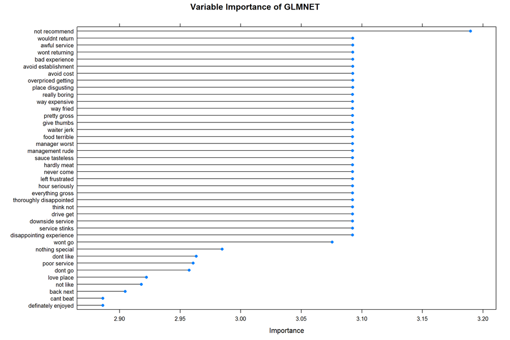

### Random Forest Results

#### - Picks up on phrases for ‘not liked’

```
## Confusion Matrix and Statistics
##
##           Reference
## Prediction  no yes
##        no   18   0
##        yes  82 100
##
##                Accuracy : 0.59
##                  95% CI : (0.5184, 0.6589)
##     No Information Rate : 0.5
##     P-Value [Acc > NIR] : 0.006565
##
##                   Kappa : 0.18
##  Mcnemar's Test P-Value : < 2.2e-16
##
##             Sensitivity : 0.1800
##             Specificity : 1.0000
##          Pos Pred Value : 1.0000
##          Neg Pred Value : 0.5495
##              Prevalence : 0.5000
##          Detection Rate : 0.0900
##    Detection Prevalence : 0.0900
##       Balanced Accuracy : 0.5900
##
##        'Positive' Class : no
##
```

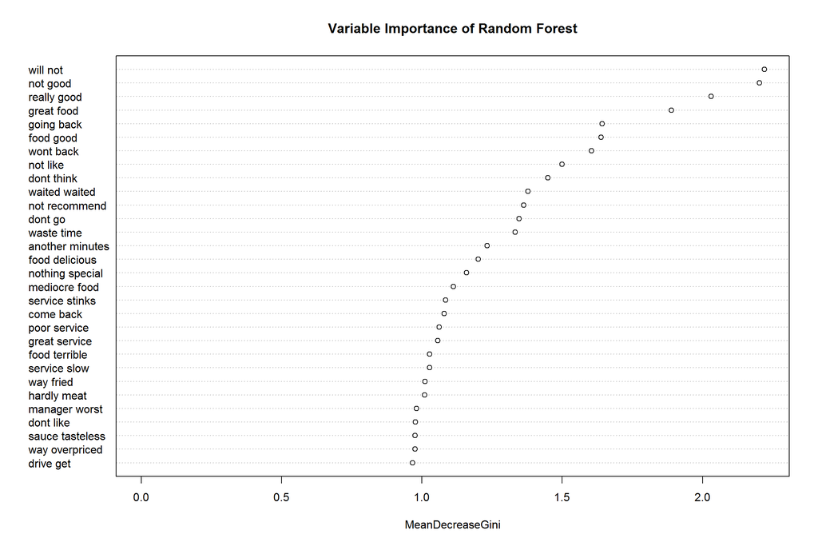

## Topic Modeling with LDA

### LDA is Latent Dirichlet Allocation

#### Each document is a mixture of topics

#### Each topic is a mixture of words; words can be shared between topics

```r
newWords <- stopwords("english")
keep <- c("no", "more", "not", "can't", "cannot", "isn't", "aren't", "wasn't",
          "weren't", "hasn't", "haven't", "hadn't", "doesn't", "don't", "didn't", "won't")
newWords <- newWords [! newWords %in% keep]

# replace punctuationc chars with space
smallWds <- function(x) {rm_nchar_words(x, "1,3")}
punctSpace <- function(x) {gsub("[[:punct:]]", " ", x)}

# clean the text
corpus = VCorpus(VectorSource(dataset_original$Review))
corpus = tm_map(corpus, content_transformer(tolower))
corpus <- tm_map(corpus, content_transformer(punctSpace))
corpus = tm_map(corpus, removeNumbers)
corpus = tm_map(corpus, removePunctuation)
corpus = tm_map(corpus, removeWords, newWords)
corpus <- tm_map(corpus, content_transformer(smallWds))
corpus = tm_map(corpus, stripWhitespace)

# tokenize
tokens <- 2
ngramTokenizer <- function(x) {RWeka::NGramTokenizer(x, RWeka::Weka_control(min = tokens, max = tokens))}
ngramDTM <- DocumentTermMatrix(corpus, control = list(tokenize = ngramTokenizer))

# use LDA, set k = 4
# Find the sum of words in each Document ensure no zeros
rowTotals <- apply(ngramDTM , 1, sum)
dtmClean   <- ngramDTM[rowTotals> 0, ]

reviews_lda <- LDA(dtmClean, k = 4, control = list(seed = 1234))
reviews_lda
```

```
## A LDA_VEM topic model with 4 topics.
```

```r
# check topics
reviews_topics <- tidy(reviews_lda, matrix = "beta")
reviews_topics
```

```
## # A tibble: 15,008 x 3
##    topic term                   beta
##    <int> <chr>                 <dbl>
##  1     1 absolute must      3.72e-44
##  2     2 absolute must      3.72e-44
##  3     3 absolute must      3.72e-44
##  4     4 absolute must      1.00e- 3
##  5     1 absolutely amazing 0.
##  6     2 absolutely amazing 3.72e-44
##  7     3 absolutely amazing 0.
##  8     4 absolutely amazing 2.00e- 3
##  9     1 absolutely back    3.72e-44
## 10     2 absolutely back    9.56e- 4
## # ... with 14,998 more rows
```

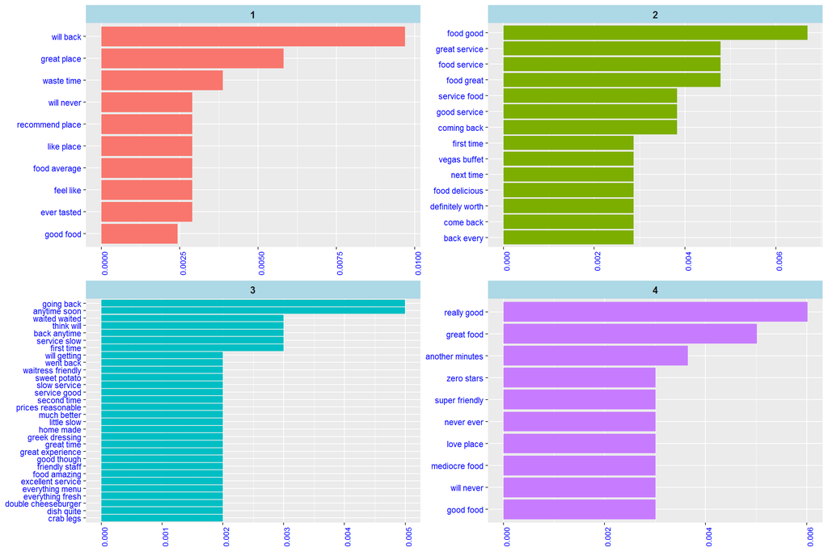

```r
# Make the plot
reviews_top_terms <- reviews_topics %>%
group_by(topic) %>%
  top_n(10, beta) %>%
  ungroup() %>%
  arrange(topic, -beta)

reviews_top_terms %>%
  mutate(term = reorder(term, beta)) %>%
  ggplot(aes(term, beta, fill = factor(topic))) +
  geom_col(show.legend = FALSE) +
  theme_bryan() +
  facet_wrap(~ topic, scales = "free") +
  coord_flip()
```